Lollipop chart

definition - mistake - related - code

# Definition

A `lollipop plot` is basically a [barplot](https://www.data-to-viz.com/graph/barplot.html), where the bar is transformed in a `line` and a `dot`. It shows the relationship between a numeric and a categoric variable.

Here is an example showing the quantity of weapons exported by the top 20 largest exporters in 2017 (more info [here](http://www.data-to-viz.com/story/OneNumOneCat.html)):

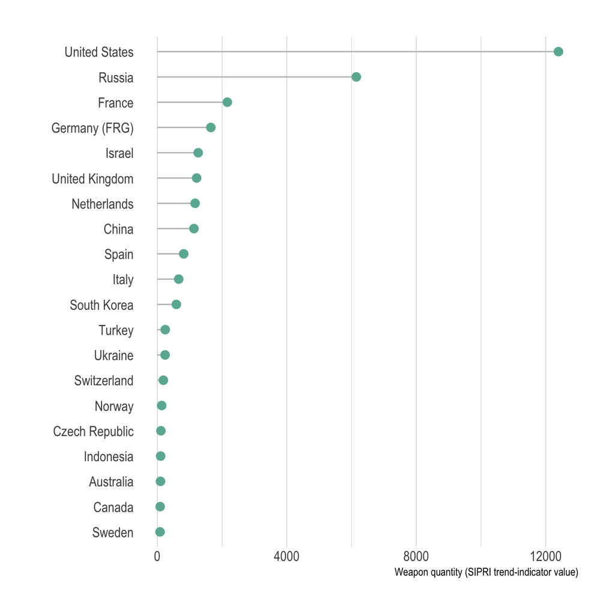

```r
# Libraries
library(tidyverse)
library(hrbrthemes)
library(kableExtra)
options(knitr.table.format = "html")
library(patchwork)

# Load dataset from github
data <- read.table("https://raw.githubusercontent.com/holtzy/data_to_viz/master/Example_dataset/7_OneCatOneNum.csv", header=TRUE, sep=",")

# Plot
data %>%
  filter(!is.na(Value)) %>%
  arrange(Value) %>%
  tail(20) %>%
  mutate(Country=factor(Country, Country)) %>%
  ggplot( aes(x=Country, y=Value) ) +
    geom_segment( aes(x=Country ,xend=Country, y=0, yend=Value), color="grey") +
    geom_point(size=3, color="#69b3a2") +
    coord_flip() +
    theme_ipsum() +
    theme(
      panel.grid.minor.y = element_blank(),
      panel.grid.major.y = element_blank(),
      legend.position="none"
    ) +
    xlab("") +
    ylab("Weapon quantity (SIPRI trend-indicator value)")
```

# What for

The lollipop plot is used exactly in the same situation than a barplot. However it is somewhat more appealing and convey as well the information. It is especially useful when you have several bars of the same height: it avoids to have a `cluttered` figure and a [Moiré effect](https://en.wikipedia.org/wiki/Moiré_pattern).

[figure not shown]

```r
don <- data.frame(
  group = LETTERS[1:20],
  val = 20 + rnorm(20)
)

p1 <- don %>%
    arrange(val) %>%
    mutate(group=factor(group, group)) %>%
    ggplot( aes(x=group, y=val) ) +
      geom_bar(stat="identity", fill="#69b3a2") +
      coord_flip() +
      theme_ipsum() +
      theme(
        panel.grid.minor.y = element_blank(),
        panel.grid.major.y = element_blank(),
        legend.position="none"
      ) +
      xlab("") +
      ylab("Weapon quantity (SIPRI trend-indicator value)")

p2 <- don %>%
    arrange(val) %>%
    mutate(group=factor(group, group)) %>%
    ggplot( aes(x=group, y=val) ) +
      geom_segment( aes(x=group ,xend=group, y=0, yend=val), color="grey") +
      geom_point(size=3, color="#69b3a2") +
      coord_flip() +
      theme_ipsum() +
      theme(
        panel.grid.minor.y = element_blank(),
        panel.grid.major.y = element_blank(),
        legend.position="none"
      ) +
      xlab("") +
      ylab("Weapon quantity (SIPRI trend-indicator value)")

p1 + p2
```

# Variation

The `Cleveland dotplot` is a handy variation, allowing to compare the value of 2 numeric values for each group. This kind of data could also be visualized using a grouped or stack [barplot](https://www.data-to-viz.com/graph/barplot.html). However, this representation is less cluttered and way easier to read. Use it if you have 2 subgroups per group.

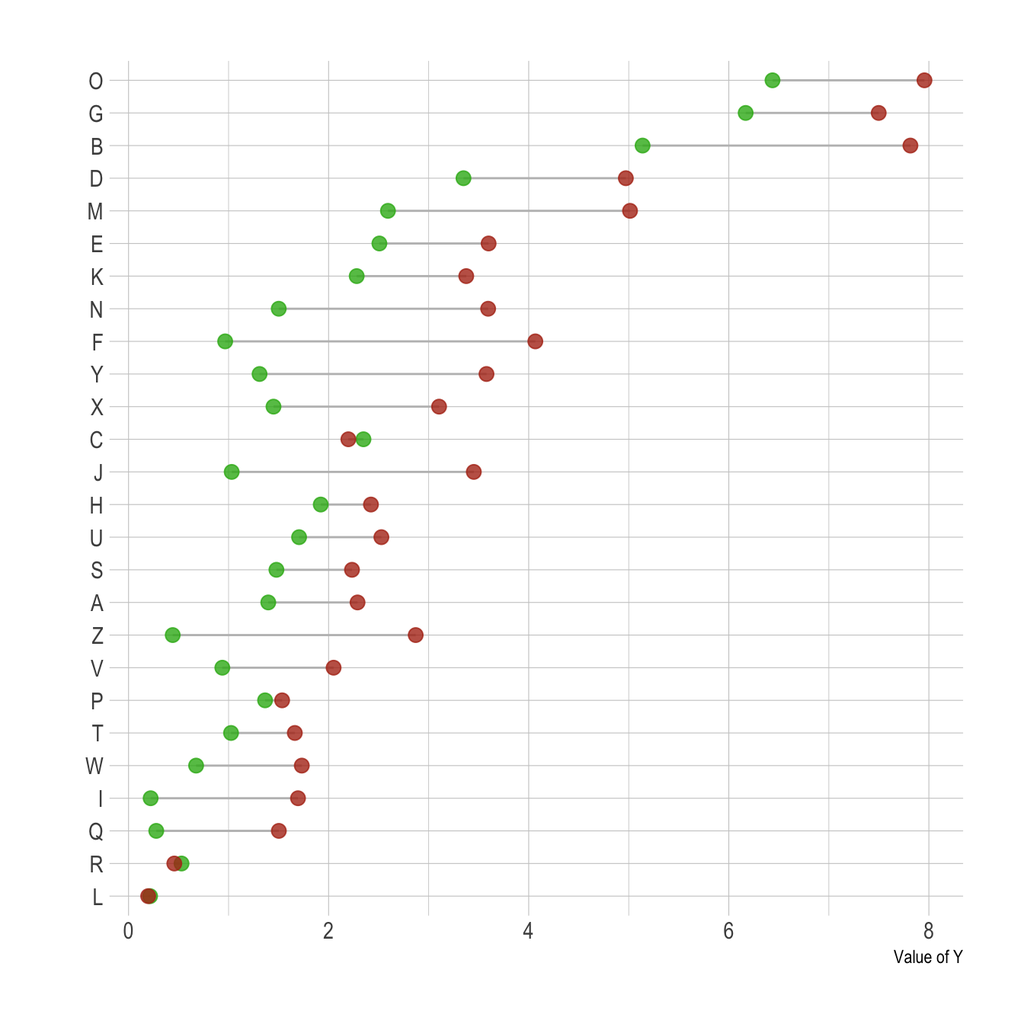

```r
# Create data (could be way easier but it's late)
value1 <- abs(rnorm(26))*2
don <- data.frame(
  x=LETTERS[1:26],
  value1=value1,
  value2=value1+1+rnorm(26, sd=1)
  ) %>%
  rowwise() %>%
  mutate( mymean = mean(c(value1,value2) )) %>%
  arrange(mymean) %>%
  mutate(x=factor(x, x))


# With a bit more style
ggplot(don) +
  geom_segment( aes(x=x, xend=x, y=value1, yend=value2), color="grey") +
  geom_point( aes(x=x, y=value1), color=rgb(0.2,0.7,0.1,0.8), size=3 ) +
  geom_point( aes(x=x, y=value2), color=rgb(0.7,0.2,0.1,0.8), size=3 ) +
  coord_flip()+
  theme_ipsum() +
  theme(
    legend.position = "none",
    panel.border = element_blank(),
  ) +
  xlab("") +
  ylab("Value of Y")
```

*Note*: The term `cleveland dotplot` does not look to be very well defined as far as I know, and looks to be sometimes used for [dotplots](http://www.joyce-robbins.com/blog/2016/06/02/datavis-with-rdrawing-a-cleveland-dot-plot-with-ggplot2/) or [classic lollipop](https://link.springer.com/chapter/10.1007/978-3-319-53019-2_11) plots as well. The previous chart is also called [Dumbbell dot plots](http://datavizproject.com/data-type/dumbbell-plot/). Further investigation is needed on this matter and any feedback is more than welcome.

Note that with a number of subgroups between 3 and ~7 this type of lollipop plot is nice as well:

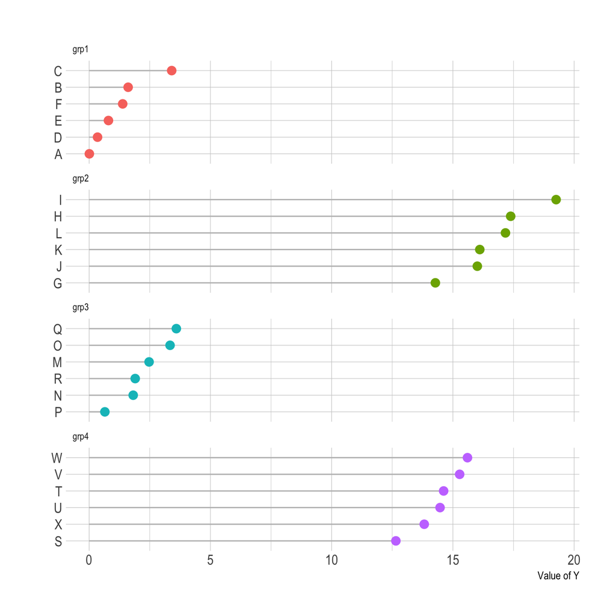

```r
# Create data (could be way easier but it's late)
value1 <- abs(rnorm(6))*2
don <- data.frame(
  x=LETTERS[1:24],
  val=c( value1, value1+1+rnorm(6, 14,1) ,value1+1+rnorm(6, sd=1) ,value1+1+rnorm(6, 12, 1) ),
  grp=rep(c("grp1", "grp2", "grp3", "grp4"), each=6)
  ) %>%
  arrange(val) %>%
  mutate(x=factor(x, x))


# With a bit more style
ggplot(don) +
  geom_segment( aes(x=x, xend=x, y=0, yend=val), color="grey") +
  geom_point( aes(x=x, y=val, color=grp), size=3 ) +
  coord_flip()+
  theme_ipsum() +
  theme(
    legend.position = "none",
    panel.border = element_blank(),
    panel.spacing = unit(0.1, "lines"),
    strip.text.x = element_text(size = 8)
  ) +
  xlab("") +
  ylab("Value of Y") +
  facet_wrap(~grp, ncol=1, scale="free_y")
```

# Common mistakes

- [Order your groups](http://www.data-to-viz.com/caveat/order_data.html). If the levels of your categoric variable have no obvious order, order the bars following their values.
- If for whatever reason your bars must remain unsorted, it is probably better to use a barplot instead. Lollipop would be harder to read.
- Several values per group? [Don’t use a lollipop](http://www.data-to-viz.com/caveat/error_bar.html). Even with error bars, it hides information and other type of graphic like [boxplot](https://www.data-to-viz.com/graph/boxplot.html) or [violin](https://www.data-to-viz.com/graph/violin.html) are much more appropriate.
- Think about the horizontal verison, it makes the labels easier to read.

# Related

Barplot

Represents the value of entities using bar of various length.

Parallel coord.

Compare samples for several numeric values.

Wordcloud

A visual representation of text data, where word size is relative to their frequency.

Boxplot

Summarize the distribution of several numeric variables using boxes. Use it if you have a limited dataset size.

# Build your own

The [R](https://www.r-graph-gallery.com) and [Python](https://www.python-graph-gallery.com) graph galleries are 2 websites providing hundreds of chart example, always providing the reproducible code. Click the button below to see how to build the chart you need with your favorite programing language.

[R graph gallery](https://www.r-graph-gallery.com/lollipop-plot/) [Python gallery](https://python-graph-gallery.com/lollipop-plot/)

# Comments

Any thoughts on this? Found any mistake? Disagree? Please drop me a word on [twitter](https://twitter.com/R_Graph_Gallery) or in the comment section below:

A work by [Yan Holtz](https://github.com/holtzy/) for data-to-viz.com